# **Loan Default Prediction**

## **Objective:**

Build a classification model to predict clients who are likely to default on their loan, and give recommendations to the bank on the important features to consider while approving a loan.

```python
import numpy as np
import pandas as pd
import matplotlib.pyplot as plt
import seaborn as sns
sns.set_theme()

from sklearn.model_selection import train_test_split

from sklearn.linear_model import LogisticRegression

from sklearn import metrics
from sklearn.metrics import confusion_matrix, classification_report,accuracy_score,precision_score,recall_score,f1_score

from sklearn import tree
from sklearn.tree import DecisionTreeClassifier

from sklearn.ensemble import BaggingClassifier
from sklearn.ensemble import RandomForestClassifier

import scipy.stats as stats

from sklearn.model_selection import GridSearchCV


import warnings
warnings.filterwarnings('ignore')
```

**Read the dataset for data evaluation**

```python
hm=pd.read_csv("/content/hmeq.csv")
```

```python
data=hm.copy()
```

```python
df = pd.read_csv("/content/hmeq.csv")
```

**Read First and Last 5 rows of the dataset**

```python
#First 5 rows
df.head()
```

|  | BAD | LOAN | MORTDUE | VALUE | REASON | JOB | YOJ | DEROG | DELINQ | CLAGE | NINQ | CLNO | DEBTINC |
| --- | --- | --- | --- | --- | --- | --- | --- | --- | --- | --- | --- | --- | --- |
| 0 | 1 | 1100 | 25860.0 | 39025.0 | HomeImp | Other | 10.5 | 0.0 | 0.0 | 94.366667 | 1.0 | 9.0 | NaN |
| 1 | 1 | 1300 | 70053.0 | 68400.0 | HomeImp | Other | 7.0 | 0.0 | 2.0 | 121.833333 | 0.0 | 14.0 | NaN |
| 2 | 1 | 1500 | 13500.0 | 16700.0 | HomeImp | Other | 4.0 | 0.0 | 0.0 | 149.466667 | 1.0 | 10.0 | NaN |
| 3 | 1 | 1500 | NaN | NaN | NaN | NaN | NaN | NaN | NaN | NaN | NaN | NaN | NaN |
| 4 | 0 | 1700 | 97800.0 | 112000.0 | HomeImp | Office | 3.0 | 0.0 | 0.0 | 93.333333 | 0.0 | 14.0 | NaN |

```python
#Last 5 rows
df.tail()
```

|  | BAD | LOAN | MORTDUE | VALUE | REASON | JOB | YOJ | DEROG | DELINQ | CLAGE | NINQ | CLNO | DEBTINC |
| --- | --- | --- | --- | --- | --- | --- | --- | --- | --- | --- | --- | --- | --- |
| 5955 | 0 | 88900 | 57264.0 | 90185.0 | DebtCon | Other | 16.0 | 0.0 | 0.0 | 221.808718 | 0.0 | 16.0 | 36.112347 |
| 5956 | 0 | 89000 | 54576.0 | 92937.0 | DebtCon | Other | 16.0 | 0.0 | 0.0 | 208.692070 | 0.0 | 15.0 | 35.859971 |
| 5957 | 0 | 89200 | 54045.0 | 92924.0 | DebtCon | Other | 15.0 | 0.0 | 0.0 | 212.279697 | 0.0 | 15.0 | 35.556590 |
| 5958 | 0 | 89800 | 50370.0 | 91861.0 | DebtCon | Other | 14.0 | 0.0 | 0.0 | 213.892709 | 0.0 | 16.0 | 34.340882 |
| 5959 | 0 | 89900 | 48811.0 | 88934.0 | DebtCon | Other | 15.0 | 0.0 | 0.0 | 219.601002 | 0.0 | 16.0 | 34.571519 |

**Observation:**

1. The dataset is loaded successfully, showing both the first and the last 5 rows, with all 13 columns.
2. The data is read correctly and is ready for further exploration.

**Shape of the dataset**

```python
#Check the shape of the data
print(data.shape)
print(f"→ {df.shape[0]} loan applicants, {df.shape[1]} features\n")
```

```
(5960, 13)
→ 5960 loan applicants, 13 features
```

**Insight: Shape of the dataset**

1. There are 5960 rows and 13 features/columns.
2. 5960 rows represents number of loan applicants and 13 features captures various evaluation in the loan application process to determine loan eligibility and approval.

**Data types of the columns**

```python
#Check info of the data
df.info()
```

```
<class 'pandas.core.frame.DataFrame'>
RangeIndex: 5960 entries, 0 to 5959
Data columns (total 13 columns):
 #   Column   Non-Null Count  Dtype
---  ------   --------------  -----
 0   BAD      5960 non-null   int64
 1   LOAN     5960 non-null   int64
 2   MORTDUE  5442 non-null   float64
 3   VALUE    5848 non-null   float64
 4   REASON   5708 non-null   object
 5   JOB      5681 non-null   object
 6   YOJ      5445 non-null   float64
 7   DEROG    5252 non-null   float64
 8   DELINQ   5380 non-null   float64
 9   CLAGE    5652 non-null   float64
 10  NINQ     5450 non-null   float64
 11  CLNO     5738 non-null   float64
 12  DEBTINC  4693 non-null   float64
dtypes: float64(9), int64(2), object(2)
memory usage: 605.4+ KB
```

**Insight: Data types**

1. There are total 5960 rows * 13 columns in the dataset.
2. Missing data/null values is significant from columns 3 to 13, of which DEBTINC has the fewest of non-null values .
3. The data types are Floats (9 columns), Integers (2 columns) and Objects ( 2 columns to classify reason for the loan and the type of jobs held by the applicants).
4. The dataset is lightweight and has only 605.4KB memory usage.

**Check for missing values**

```python
#Analyze missing values
df.isnull()
```

|  | BAD | LOAN | MORTDUE | VALUE | REASON | JOB | YOJ | DEROG | DELINQ | CLAGE | NINQ | CLNO | DEBTINC |
| --- | --- | --- | --- | --- | --- | --- | --- | --- | --- | --- | --- | --- | --- |
| 0 | False | False | False | False | False | False | False | False | False | False | False | False | True |
| 1 | False | False | False | False | False | False | False | False | False | False | False | False | True |
| 2 | False | False | False | False | False | False | False | False | False | False | False | False | True |
| 3 | False | False | True | True | True | True | True | True | True | True | True | True | True |
| 4 | False | False | False | False | False | False | False | False | False | False | False | False | True |
| ... | ... | ... | ... | ... | ... | ... | ... | ... | ... | ... | ... | ... | ... |
| 5955 | False | False | False | False | False | False | False | False | False | False | False | False | False |
| 5956 | False | False | False | False | False | False | False | False | False | False | False | False | False |
| 5957 | False | False | False | False | False | False | False | False | False | False | False | False | False |
| 5958 | False | False | False | False | False | False | False | False | False | False | False | False | False |
| 5959 | False | False | False | False | False | False | False | False | False | False | False | False | False |

5960 rows × 13 columns

```python
#Check for count and % of missing values in each column
missing_val_count = df.isnull().sum()
missing_val_percent = 100 * missing_val_count / len(df)
missing_val_table = pd.DataFrame({
    'Missing Count': missing_val_count,
    'Missing %': missing_val_percent
})

print(missing_val_table)
```

```
         Missing Count  Missing %
BAD                  0   0.000000
LOAN                 0   0.000000
MORTDUE            518   8.691275
VALUE              112   1.879195
REASON             252   4.228188
JOB                279   4.681208
YOJ                515   8.640940
DEROG              708  11.879195
DELINQ             580   9.731544
CLAGE              308   5.167785
NINQ               510   8.557047
CLNO               222   3.724832
DEBTINC           1267  21.258389
```

**Analysis and Observation: Missing values in columns & Challenges with Imputing and Dropping**

It can be noted that the % of missing data for feature "DEBTINC" is the highest, ~21.26% and most other features also show low to moderate % of missing values.

Even though the missing count provides accurate number of missing data per feature, % value helps in determining the limit and impact to plan for Dropping or Imputation methods to buld a more meaningful classification model.

**I. For % missing value:**

There are general guidelines (not specific) from statistical and data science studies, for % missing values and its impact on data analysis:

1. < 5% is generally considered low. Imputation methods are usually effective and the impact on analysis or model performance is minimal.
2. 5% - 20% is considered moderate. Imputation could still be an option, but requires more sophisticated methods and domain knowledge and expertise.
3. More than > 20% is High and warrants careful consideration. We might consider dropping the column if it's not critical

**II. Challenges associated with filling (Imputing) missing values:**

1. Bias Introduction: Introducing bias if the imputation method doesn't accurately refflect the true underlying distribution of the missing data. Simple methods like mean or median imputation can distort variance and relationships.
2. Increased variance: Leading to an artificial reduction in variance, making the data appear more homogeneous than it is.
3. Loss of Information: If the missing data had informative information, replacing with imputed data might destroy the signal.
4. Complexity and Computational Cost: Advanced methods like K-Nearest Neighbors and others can be computationally intensive and complex to implement and validate.
5. Assumption Violations: Known techniques rely on standard assumptions and these can be violated.

**III. Challenges associated with Dropping (Avoiding) values and features:**

1. Loss of data/statistics: **Dropping rows** can significantly reduce the sample size, resulting in less reliable models.
2. Reduced model performance: **Dropping a feature** or a column means discarding potentially useful signal, perhaps a more important feature that may lead to poor model output predictions
3. Inaccurate Population representation: Model trained on a subset of data might not represent a full population, leading to inaccurate or biased data input.

**Convert data types**

Converting "Objects" to "Category" reduces the data space required to store the dataframe

```python
cols = df.select_dtypes(['object']).columns.tolist()
```

```python
cols
```

```
['REASON', 'JOB']
```

```python
# Changing the data type of object type column to category.

for i in cols:
    df[i] = df[i].astype('category')
```

```python
df.info()
```

```
<class 'pandas.core.frame.DataFrame'>
RangeIndex: 5960 entries, 0 to 5959
Data columns (total 13 columns):
 #   Column   Non-Null Count  Dtype
---  ------   --------------  -----
 0   BAD      5960 non-null   int64
 1   LOAN     5960 non-null   int64
 2   MORTDUE  5442 non-null   float64
 3   VALUE    5848 non-null   float64
 4   REASON   5708 non-null   category
 5   JOB      5681 non-null   category
 6   YOJ      5445 non-null   float64
 7   DEROG    5252 non-null   float64
 8   DELINQ   5380 non-null   float64
 9   CLAGE    5652 non-null   float64
 10  NINQ     5450 non-null   float64
 11  CLNO     5738 non-null   float64
 12  DEBTINC  4693 non-null   float64
dtypes: category(2), float64(9), int64(2)
memory usage: 524.3 KB
```

**Analyze summary statistics of the dataset**

```python
## Analyze statistical summary for numerical variables
df.describe().T
```

|  | count | mean | std | min | 25% | 50% | 75% | max |
| --- | --- | --- | --- | --- | --- | --- | --- | --- |
| BAD | 5960.0 | 0.199497 | 0.399656 | 0.000000 | 0.000000 | 0.000000 | 0.000000 | 1.000000 |
| LOAN | 5960.0 | 18607.969799 | 11207.480417 | 1100.000000 | 11100.000000 | 16300.000000 | 23300.000000 | 89900.000000 |
| MORTDUE | 5442.0 | 73760.817200 | 44457.609458 | 2063.000000 | 46276.000000 | 65019.000000 | 91488.000000 | 399550.000000 |
| VALUE | 5848.0 | 101776.048741 | 57385.775334 | 8000.000000 | 66075.500000 | 89235.500000 | 119824.250000 | 855909.000000 |
| YOJ | 5445.0 | 8.922268 | 7.573982 | 0.000000 | 3.000000 | 7.000000 | 13.000000 | 41.000000 |
| DEROG | 5252.0 | 0.254570 | 0.846047 | 0.000000 | 0.000000 | 0.000000 | 0.000000 | 10.000000 |
| DELINQ | 5380.0 | 0.449442 | 1.127266 | 0.000000 | 0.000000 | 0.000000 | 0.000000 | 15.000000 |
| CLAGE | 5652.0 | 179.766275 | 85.810092 | 0.000000 | 115.116702 | 173.466667 | 231.562278 | 1168.233561 |
| NINQ | 5450.0 | 1.186055 | 1.728675 | 0.000000 | 0.000000 | 1.000000 | 2.000000 | 17.000000 |
| CLNO | 5738.0 | 21.296096 | 10.138933 | 0.000000 | 15.000000 | 20.000000 | 26.000000 | 71.000000 |
| DEBTINC | 4693.0 | 33.779915 | 8.601746 | 0.524499 | 29.140031 | 34.818262 | 39.003141 | 203.312149 |

**Insight: Statistical summary of Numerical variables**

Based on the output, we can draw several insights regarding the numerical features:

- **Target Variable (BAD):** The average value is approximately 0.199, indicating that around 19.9% of the loan applicants in the dataset have defaulted. This reveals a class imbalance that will need to be addressed during model training.
- **Financial Metrics (LOAN, MORTDUE, VALUE, DEBTINC):**
  - LOAN amounts are concentrated at the lower end, with a median of $16,300 and a max of $89,900. This suggests most loans are for relatively smaller amounts.
  - MORTDUE and VALUE show significant spread, indicating a diverse range of mortgage statuses and property values among applicants. Both have missing values, with MORTDUE having a higher count.
  - DEBTINC (Debt-to-Income ratio) has the highest percentage of missing values (21.26%) and a very wide range, including extreme outliers (max 203.31%). This feature will require careful handling (imputation and potentially outlier treatment) due to its high missingness and extreme values, yet it's often a critical predictor of loan default.
- **Credit History & Behavior (YOJ, DEROG, DELINQ, CLAGE, NINQ, CLNO):**
  - YOJ (Years on Job) has a mean of ~8.9 years, suggesting a moderately experienced workforce, but with a wide range (0-41 years).
  - DEROG (Derogatory Marks) and DELINQ (Delinquent Accounts) both have low means but high maximums, indicating that while most applicants have few or no negative marks, some have many, which could be strong indicators of default risk.
  - CLAGE (Age of Oldest Credit Line) shows a broad distribution, with credit histories ranging from new (0 months) to very established (over 1168 months).
  - NINQ (Number of Recent Credit Inquiries) and CLNO (Number of Credit Lines) also show wide ranges, suggesting varied credit seeking behavior and credit portfolio sizes among applicants.

**Overall Conclusion for Numerical Data:**

The numerical features exhibit considerable variability and contain missing values, especially in DEBTINC, MORTDUE, YOJ, DEROG, DELINQ, CLAGE, and NINQ. Outliers are also present in several features (e.g., VALUE, DELINQ, DEBTINC). These characteristics highlight the necessity for robust preprocessing steps, including imputation of missing values, outlier detection and handling, and potentially feature scaling or transformation, before model building.

```python
# Analyze summary for categorical variables

df.describe(include='category').T
```

|  | count | unique | top | freq |
| --- | --- | --- | --- | --- |
| REASON | 5708 | 2 | DebtCon | 3928 |
| JOB | 5681 | 6 | Other | 2388 |

**Insight: Statistical summary of Categorical variable**

Categorical data summary provides a broader view of unique data types for each category, followed by the top most category featuring high frequency. But limits statistical inference for further analysis and modeling

**View into Unique values in the categorical variables:**

```python
# Checking the count of unique values in each categorical column

cols_cat= df.select_dtypes(['category'])

for i in cols_cat.columns:
    print('Unique values in',i, 'are :')
    print(df[i].unique())
    print('='*50)
```

```
Unique values in REASON are :
['HomeImp', NaN, 'DebtCon']
Categories (2, object): ['DebtCon', 'HomeImp']
==================================================
Unique values in JOB are :
['Other', NaN, 'Office', 'Sales', 'Mgr', 'ProfExe', 'Self']
Categories (6, object): ['Mgr', 'Office', 'Other', 'ProfExe', 'Sales', 'Self']
==================================================
```

**Observation/Insight:**

From the output, it can be observed that both, REASON and JOB columns, still contain "NaN" (Not a Number) values, even after converting them to "category" data type. And to address these, we will have to modify the data either through imputation or by treating "NaN" as a distinct category, before they can be used effectively in modeling.

**Re-Analyze the Categorical variables to view unique values:**

```python
for col in cols_cat.columns:
    print(f'Value counts and percentages for {col}:')
    value_counts = df[col].value_counts(dropna=False) # Include NaN counts
    value_percentages = df[col].value_counts(normalize=True, dropna=False) * 100 # Include NaN percentages

    # Combine into a single DataFrame for better display
    combined_df = pd.DataFrame({
        'Count': value_counts,
        'Percentage': value_percentages
    })
    display(combined_df)
    print('='*50)
```

```
Value counts and percentages for REASON:
```

| REASON | Count | Percentage |
| --- | --- | --- |
| DebtCon | 3928 | 65.906040 |
| HomeImp | 1780 | 29.865772 |
| NaN | 252 | 4.228188 |

```
==================================================
Value counts and percentages for JOB:
```

| JOB | Count | Percentage |
| --- | --- | --- |
| Other | 2388 | 40.067114 |
| ProfExe | 1276 | 21.409396 |
| Office | 948 | 15.906040 |
| Mgr | 767 | 12.869128 |
| NaN | 279 | 4.681208 |
| Self | 193 | 3.238255 |
| Sales | 109 | 1.828859 |

**Insight:Revised measure statistical summary of Categorical variable**

1. Even though Absolute counts are useful, relative frequencies (percentages) often provide a more insightful view of the distribution within categorical variables.
2. 'OTHER' Job Category: Under Job Categories, 'Other' is dominant, ruling 40.07% of the data uniqueness, suggesting a broad range of professions not fitting specific categories.
3. Missing Values: Similar to 'REASON', about 4.68% of the 'JOB' entries are missing. This also requires careful consideration for imputation or treatment.

## **Exploratory Data Analysis (EDA) and Visualization**

#### **1. Univariate Analysis - Numerical Data (Histogram and Boxplots)**

```python
# While doing uni-variate analysis of numerical variables we want to study their central tendency and dispersion.
# Let us write a function that will help us create boxplot and histogram for any input numerical variable.
# This function takes the numerical column as the input and return the boxplots and histograms for the variable.
# Let us see if this help us write faster and cleaner code.
def histogram_boxplot(feature, figsize=(15,10), bins = None):
    """ Boxplot and histogram combined
    feature: 1-d feature array
    figsize: size of fig (default (9,8))
    bins: number of bins (default None / auto)
    """
    f2, (ax_box2, ax_hist2) = plt.subplots(nrows = 2, # Number of rows of the subplot grid= 2
                                           sharex = True, # x-axis will be shared among all subplots
                                           gridspec_kw = {"height_ratios": (.25, .75)},
                                           figsize = figsize
                                           ) # creating the 2 subplots
    sns.boxplot(feature, ax=ax_box2, showmeans=True, color='violet') # boxplot will be created and a star will indicate the mean value of the column
    sns.histplot(feature, kde=F, ax=ax_hist2, bins=bins,palette="winter") if bins else sns.histplot(feature, kde=False, ax=ax_hist2) # For histogram
    ax_hist2.axvline(np.mean(feature), color='green', linestyle='--') # Add mean to the histogram
    ax_hist2.axvline(np.median(feature), color='black', linestyle='-') # Add median to the histogram
```

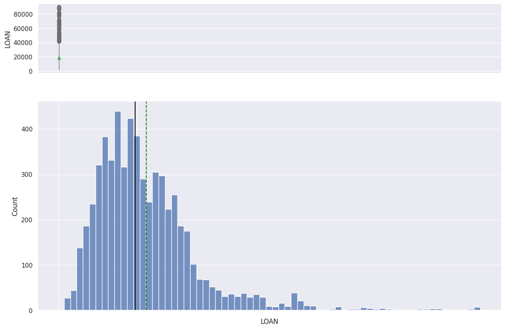

```python
# Build the histogram boxplot for Loan (Amount of loan approved)
histogram_boxplot(df['LOAN'])
```

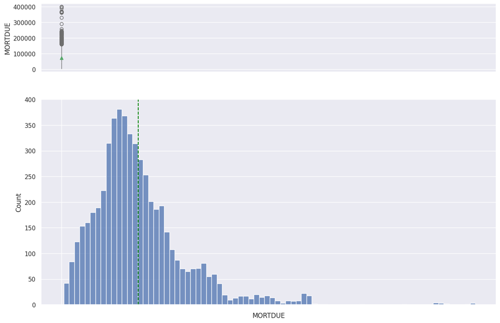

```python
# Build the histogram boxplot for MORTDUE (Amount due on the existing mortgage)
histogram_boxplot(df['MORTDUE'])
```

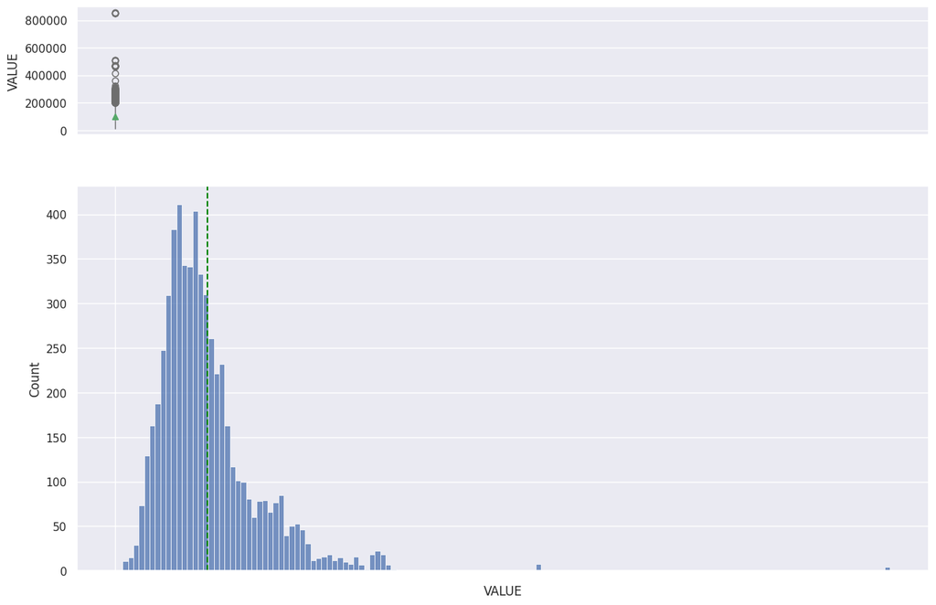

```python
# Build the histogram boxplot for VALUE (Current value of the property)
histogram_boxplot(df['VALUE'])
```

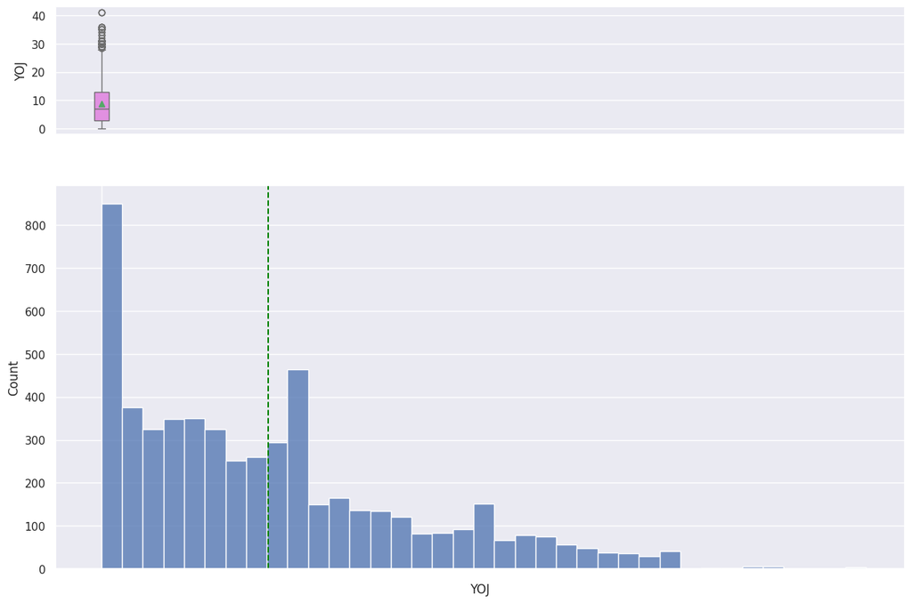

```python
# Build the histogram boxplot for YOJ (Years at present job)
histogram_boxplot(df['YOJ'])
```

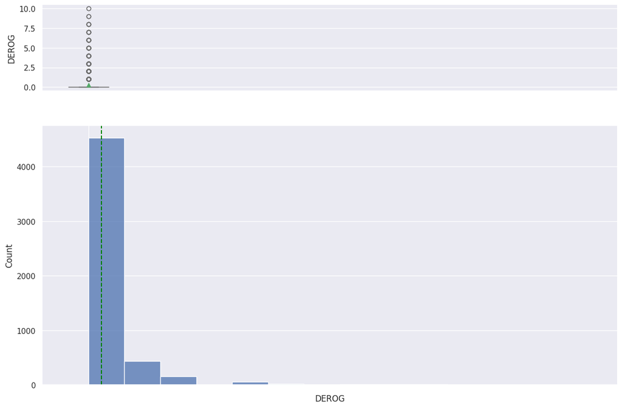

```python
# Build the histogram boxplot for DEROG (# of derogatory reports)
histogram_boxplot(df['DEROG'])
```

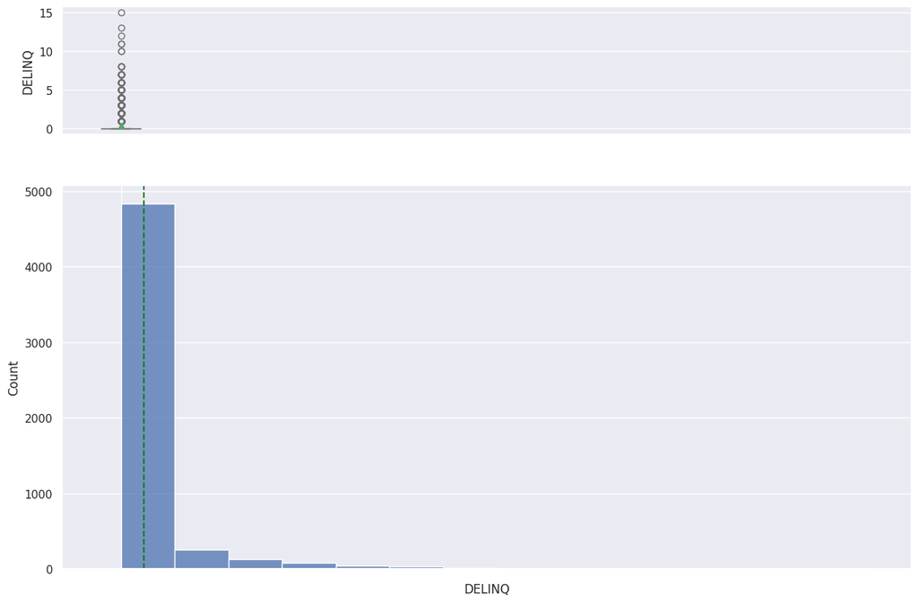

```python
# Build the histogram boxplot for DELINQ (# of delinquent credit lines)
histogram_boxplot(df['DELINQ'])
```

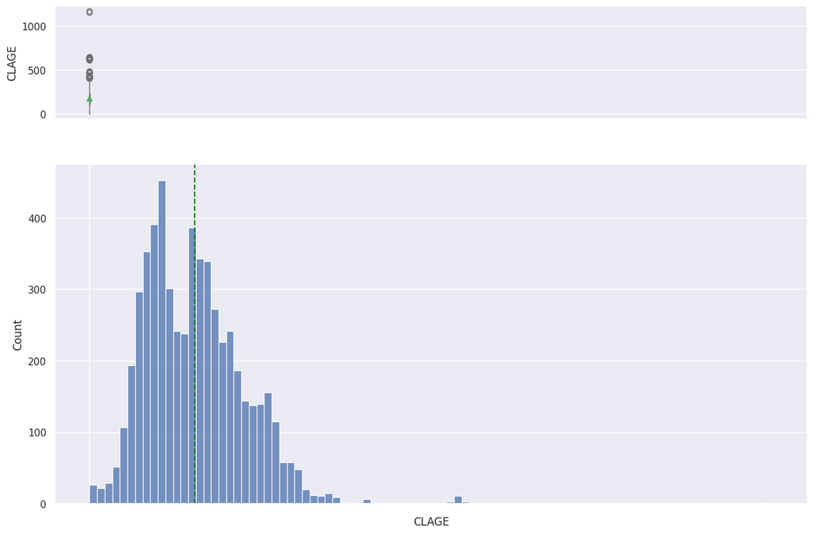

```python
# Build the histogram boxplot for CLAGE (Age of the oldest credit line in months)
histogram_boxplot(df['CLAGE'])
```

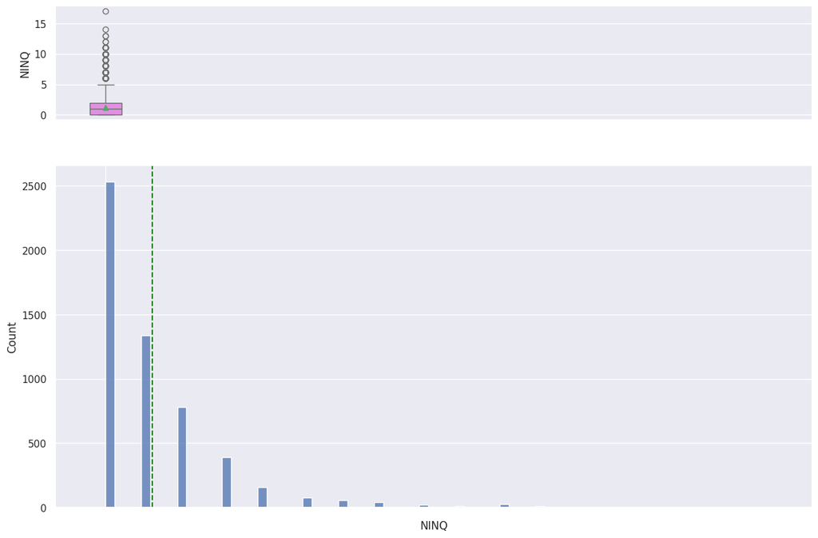

```python
# Build the histogram boxplot for NINQ (# of recent credit inquiries)
histogram_boxplot(df['NINQ'])
```

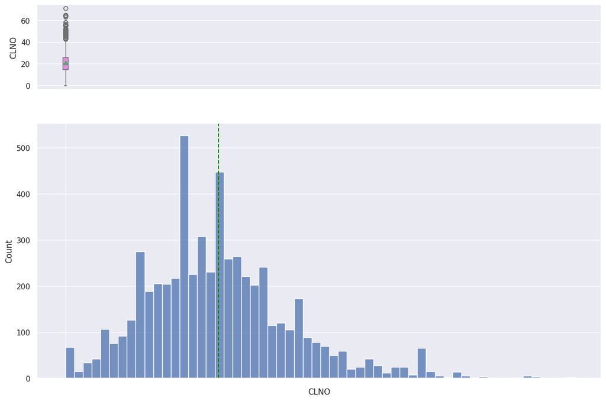

```python
# Build the histogram boxplot for CLNO (# of existing credit lines)
histogram_boxplot(df['CLNO'])
```

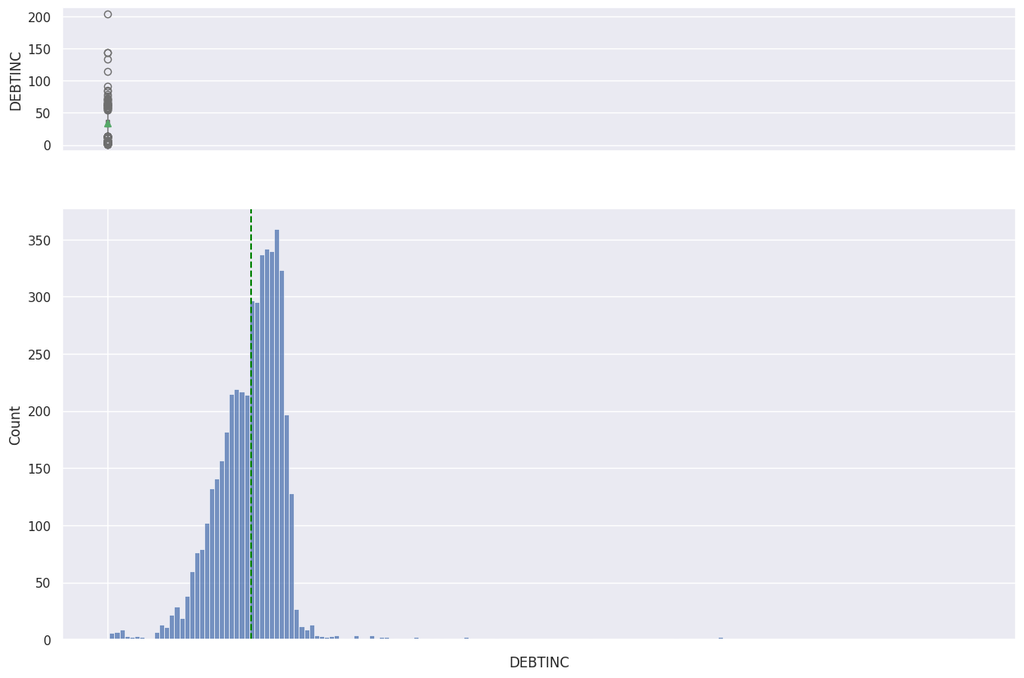

```python
# Build the histogram boxplot for DEBTINC (Debt-to-income ratio)
histogram_boxplot(df['DEBTINC'])
```

#### **2. Univariate Analysis - Categorical Data (Barplot)**

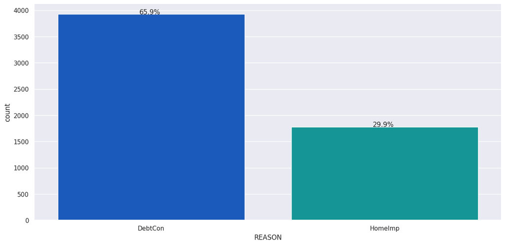

```python
# Function to create barplots that indicate percentage for each category.

def perc_on_bar(plot, feature):
    total = len(feature) # length of the column
    for p in ax.patches:
        percentage = '{:.1f}%'.format(100 * p.get_height()/total) # percentage of each class of the category
        x = p.get_x() + p.get_width() / 2 - 0.05 # width of the plot
        y = p.get_y() + p.get_height()           # height of the plot
        ax.annotate(percentage, (x, y), size = 12) # annotate the percentage

    plt.show()

#Build barplot for REASON
fig, ax = plt.subplots(figsize=(15,7))
ax = sns.countplot(data=df, x='REASON', palette="winter")
perc_on_bar(ax, df['REASON'])
```

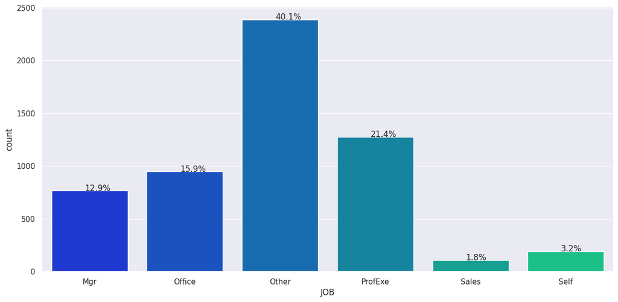

```python
#Build barplot for JOB
fig, ax = plt.subplots(figsize=(15,7))
ax = sns.countplot(data=df, x='JOB', palette="winter")
perc_on_bar(plot=ax, feature=df['JOB'])
```

#### **Univariate Analysis - Numerical variables (Barplot):**

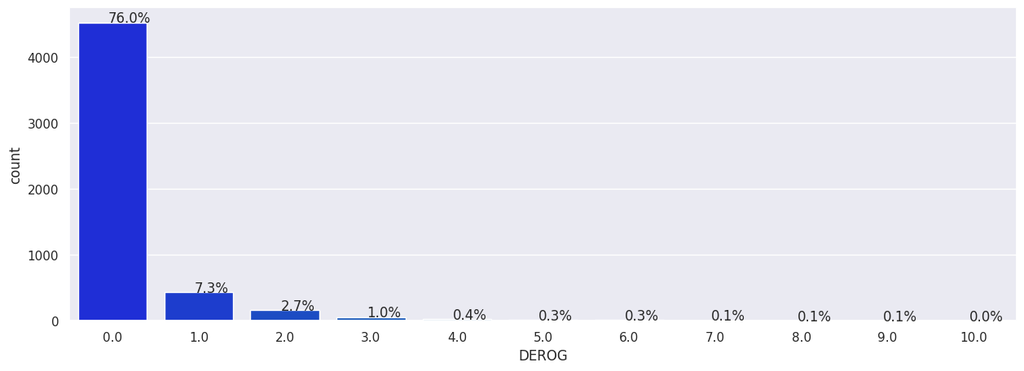

```python
#Build barplot for DEROG

plt.figure(figsize=(15,5))
ax = sns.countplot(x=df["DEROG"],palette='winter')
perc_on_bar(ax,df["DEROG"])
```

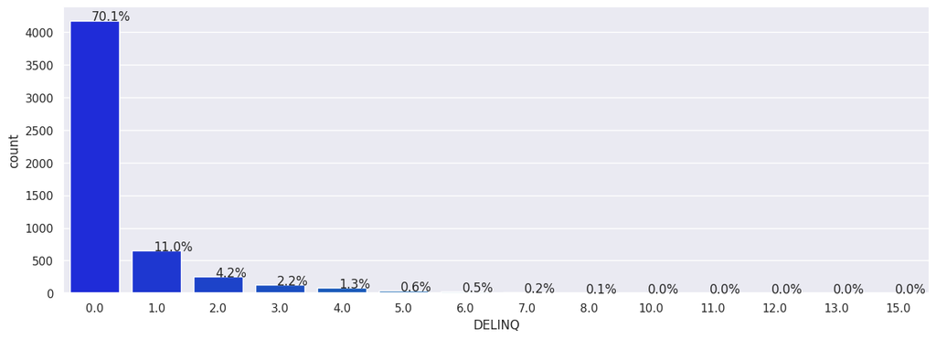

```python
#Build barplot for DELINQ

plt.figure(figsize=(15,5))
ax = sns.countplot(x=df["DELINQ"],palette='winter')
perc_on_bar(ax,df["DELINQ"])
```

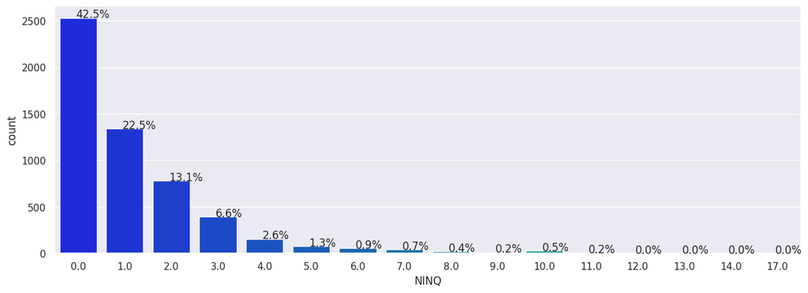

```python
#Build barplot for NINQ

plt.figure(figsize=(15,5))
ax = sns.countplot(x=df["NINQ"],palette='winter')
perc_on_bar(ax,df["NINQ"])
```

#### **Bivariate Analysis**

**Bivariate Analysis: Continuous and Categorical Variables (Boxplot)**

**BAD VS LOAN: Do larger loan amounts associate with higher default risk**

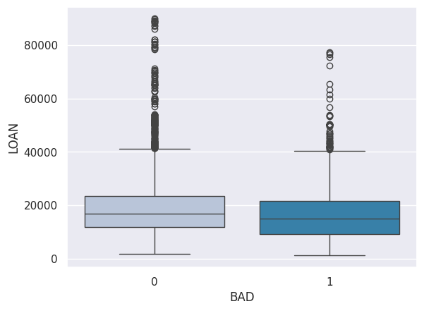

```python
# Build plot to analyze BAD vs LOAN

sns.boxplot(x=df["BAD"],y=df['LOAN'],palette="PuBu")
```

**BAD VS MORTDUE: Does existing mortgage debt relate to default**

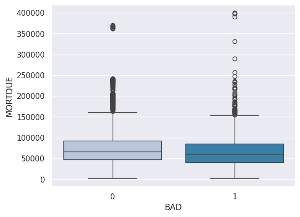

```python
# Build plot to analyze BAD vs MORTDUE

sns.boxplot(x=df["BAD"],y=df['MORTDUE'],palette="PuBu")
```

**BAD VS VALUE: Does the value of the property owned matter**

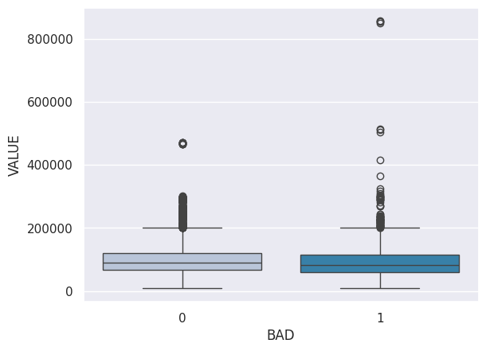

```python
# Build plot to analyze BAD vs VALUE

sns.boxplot(x=df["BAD"],y=df['VALUE'],palette="PuBu")
```

**BAD VS YOJ: Does the job tenure (years on job) protect against default**

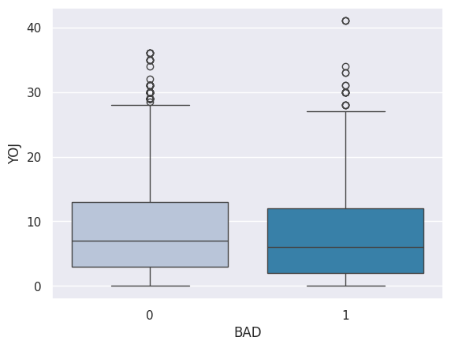

```python
# Build plot to analyze BAD vs YOJ

sns.boxplot(x=df["BAD"],y=df['YOJ'],palette="PuBu")
```

**BAD VS DEROG: Do derogatory reports predict default**

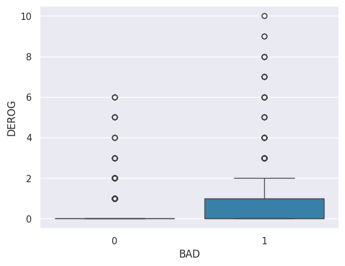

```python
# Build plot to analyze BAD vs DEROG

sns.boxplot(x=df["BAD"],y=df['DEROG'],palette="PuBu")
```

**BAD VS DELINQ: Do past delinquencies predict future default**

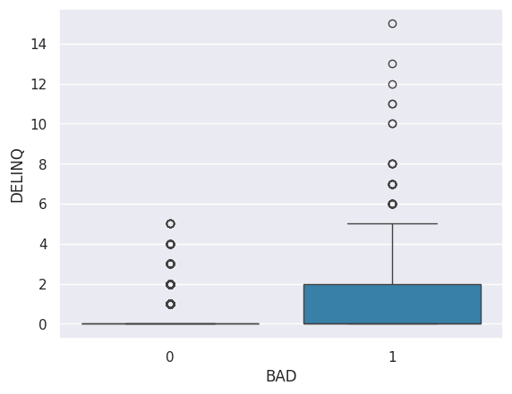

```python
# Build plot to analyze BAD vs DELINQ

sns.boxplot(x=df["BAD"],y=df['DELINQ'],palette="PuBu")
```

**BAD VS CLAGE: Does age of oldest credit line matter**

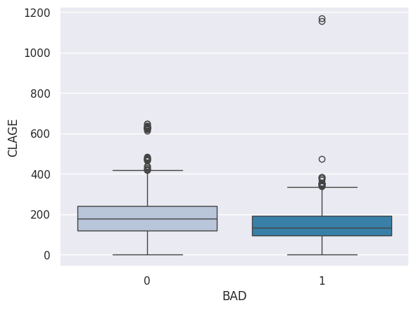

```python
# Build plot to analyze BAD vs CLAGE

sns.boxplot(x=df["BAD"],y=df['CLAGE'],palette="PuBu")
```

**BAD VS NINQ: Does number of recent credit inquiries relate to risk**

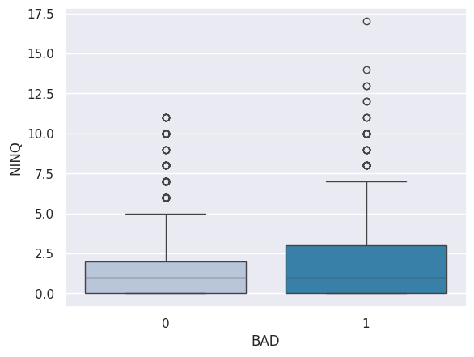

```python
# Build plot to analyze BAD vs NINQ

sns.boxplot(x=df["BAD"],y=df['NINQ'],palette="PuBu")
```

**BAD VS CLNO: Does number of credit lines relate to default**

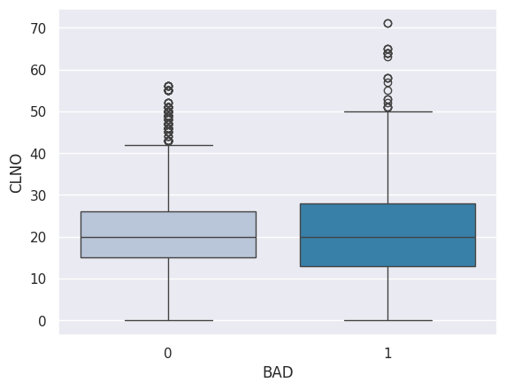

```python
# Build plot to analyze BAD vs CLNO

sns.boxplot(x=df["BAD"],y=df['CLNO'],palette="PuBu")
```

**BAD VS DEBTINC: Does debt-to-income ratio predict default on loan payments**

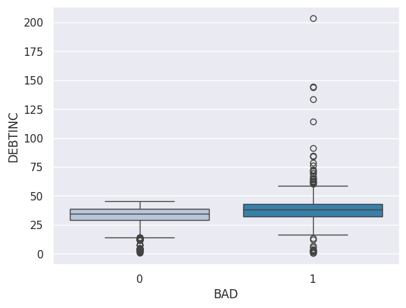

```python
# Build plot to analyze BAD vs DEBTINC

sns.boxplot(x=df["BAD"],y=df['DEBTINC'],palette="PuBu")
```

**Insight: From the Bi-variate plots:**

1. **BAD vs LOAN:** Defaulters have a slightly lower median loan amount (14,900) than the non-defaulters (16,900).
2. **BAD vs MORTDUE:** Similarly, defaulters carry slightly less existing mortgage debt (60,279 vs 66,839).
3. **BAD VS VALUE:** Defaulters tend to own less valuable properties (82,900 vs 90,659), hinting that lower home value may correlate with mildly higher default risk.
4. **BAD vs YOJ:**Though the correlation between these features in the following analysis shows (+/-) relationship, Job tenure is nearly identical between both groups.
5. **BAD vs DEROG:** Defaulters more frequently have 1+ derogarotory reports thatn the median itself, as the median is 0.
6. **BAD vs DELINQ:** Median 0 for both, but the outliers reveal that defaulters skew toward more delinquencies.
7. **BAD vs CLAGE:** Defaulters have notably shorter credit history
8. **BAD vs NINQ:** Median is identical, though the reading from the tail (frequent inquiries) may still differ.
9. **BAD vs CLNO:**Medians are the same, suggesting number of credit lines alone doesn't meaningfully distinguish the groups.
10. **BAD vs DEBTINC:** Defaulters have a noticeably higher median debt-to-income ratio, and combined with correlation results, confirms DEBTINC as one of the more meaningful predictors of default

#### **Bivariate Analysis: Two Continuous Variables**

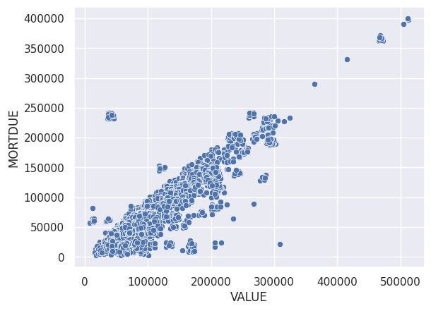

```python
#Build a scatterplot for 2 continous variable
sns.scatterplot(x=df["VALUE"],y=df['MORTDUE'],palette="PuBu")
```

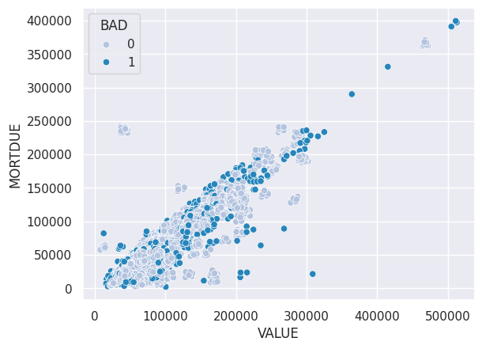

```python
# Build a scatterplot for 2 same variables, VALUE (X-Axis) and MORTDUE(Y-Axis)
#and enhance by coloring points with hue='BAD'

sns.scatterplot(x=df["VALUE"],y=df['MORTDUE'],hue=df['BAD'],palette="PuBu")
```

**Insight: From the scatterplot on positive correlationship between variables**

There's clearly a strong positive correlation between VALUE and MORTDUE. As the current value of the property (VALUE) increases, the amount due on the existing mortgage (MORTDUE) also tends to increase. This is an expected relationship, as higher-valued properties generally come with larger mortgages.

**Distribution of Defaulting vs. Non-Defaulting Loans:**

Both 0 (Non-Default) and 1(Default) on loans follow the general positive trend. However, BAD=1 customers appear to be more scattered, particularly when MORTDUE is relatively high compared to VALUE, or for lower to mid-range property values.

This suggests that a higher loan-to-value ratio (LTV), or simply having a significant mortgage even on a moderately valued property, might be a characteristic associated with default.

**Bivariate Analysis: BAD vs Categorical Variables**

```python
### Function to plot stacked bar charts for categorical columns

def stacked_plot(x):
    sns.set(palette='nipy_spectral')
    tab1 = pd.crosstab(x,df['BAD'],margins=True)
    print(tab1)
    print('-'*120)
    tab = pd.crosstab(x,df['BAD'],normalize='index')
    tab.plot(kind='bar',stacked=True,figsize=(10,5))
    plt.legend(loc='lower left', frameon=False)
    plt.legend(loc="upper left", bbox_to_anchor=(1,1))
    plt.show()
```

**Stacked bar plot for BAD vs REASON**

```
BAD         0     1   All
REASON
DebtCon  3183   745  3928
HomeImp  1384   396  1780
All      4567  1141  5708
------------------------------------------------------------------------------------------------------------------------
```

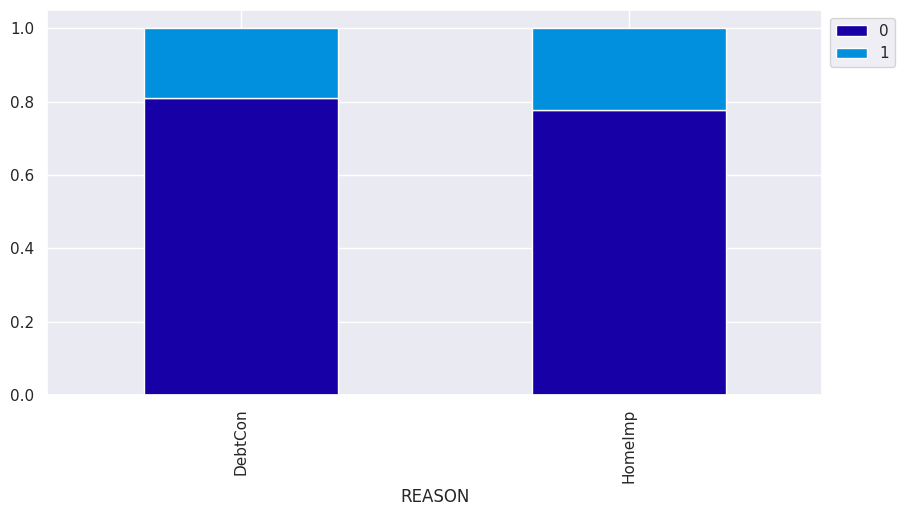

```python
# Plot stacked bar plot for BAD and REASON
stacked_plot(df['REASON'])
```

**Insight: From the stacked bar plot for BAD vs REASON**

we can derive the following insights:

**DebtCon:** Debt Consolidation seem to be the most common reason for loans, accounting for a larger number of applications (3928) compared to 'HomeImp' (Home Improvement) (1780).

**Default Rate Comparison:** For 'DebtCon' loans, approximately 18.96% (745 out of 3928) resulted in default. For 'HomeImp' loans, approximately 22.25% (396 out of 1780) resulted in default. This indicates that while 'DebtCon' loans are more frequent, **'HomeImp' loans have a slightly higher proportion of defaults.**

**Stacked bar plot for BAD vs JOB**

```
BAD         0     1   All
JOB
Mgr       588   179   767
Office    823   125   948
Other    1834   554  2388
ProfExe  1064   212  1276
Sales      71    38   109
Self      135    58   193
All      4515  1166  5681
------------------------------------------------------------------------------------------------------------------------
```

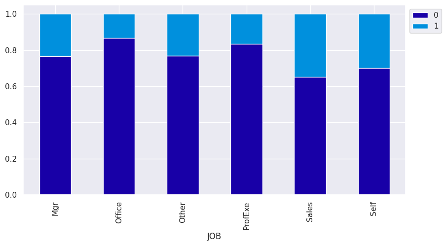

```python
# Plot stacked bar plot for BAD and REASON
stacked_plot(df['JOB'])
```

**Insight: From the stacked bar plot for BAD vs JOB**

**Job Distribution:**

**Other** is the most frequent job category, followed by 'ProfExe' and 'Office'. 'Sales' and 'Self' are the least frequent.

**Default Rate by Job Category:**

**Sales** has the highest default rate among all categories, with approximately 34.86% (38 out of 109) of loans in this category resulting in default.

**Self** also shows a relatively high default rate at around 30.05% (58 out of 193).

**ProfExe** (Professional Executive) has a **lower default rate** of about 16.61% (212 out of 1276).

**Office has the lowest default** rate at approximately 13.19% (125 out of 948).

This indicates that job categories like 'Sales' and 'Self' might be associated with a higher risk of loan default, while 'Office' and 'ProfExe' appear to have lower default rates.

### **Multivariate Analysis**

**Analyze Correlation Heatmap for Numerical Variables**

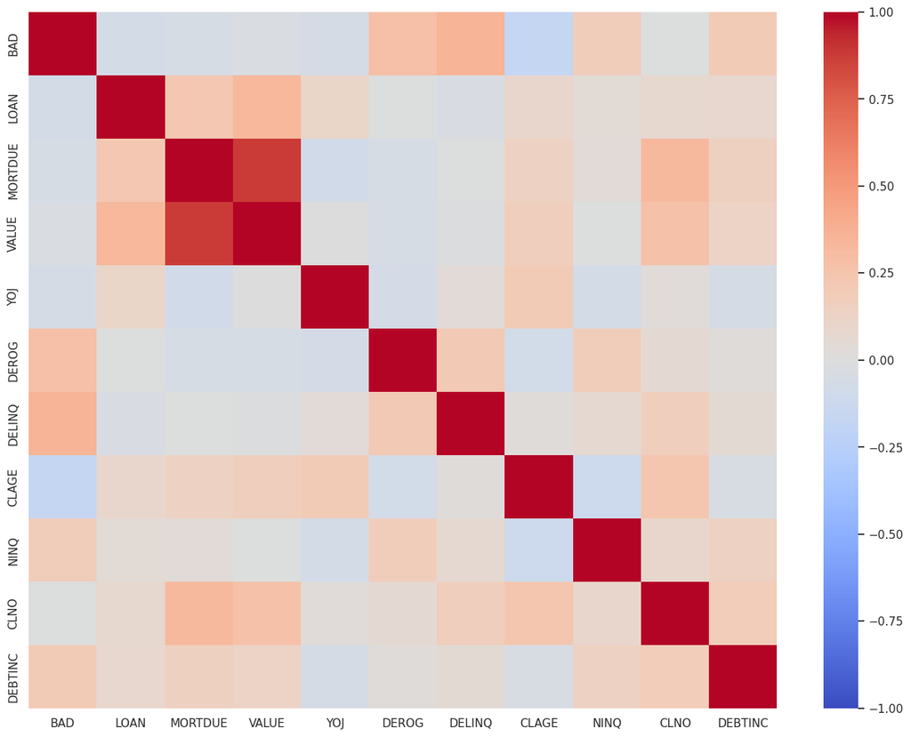

```python
# Separating numerical variables
numerical_col = df.select_dtypes(include=np.number).columns.tolist()

# Build correlation matrix for numerical columns
corr = df[numerical_col].corr()

# Plot the heatmap
plt.figure(figsize=(16,12))
sns.heatmap(corr,cmap='coolwarm',vmax=1,vmin=-1,
        fmt=".2f",
        xticklabels=corr.columns,
        yticklabels=corr.columns);
```

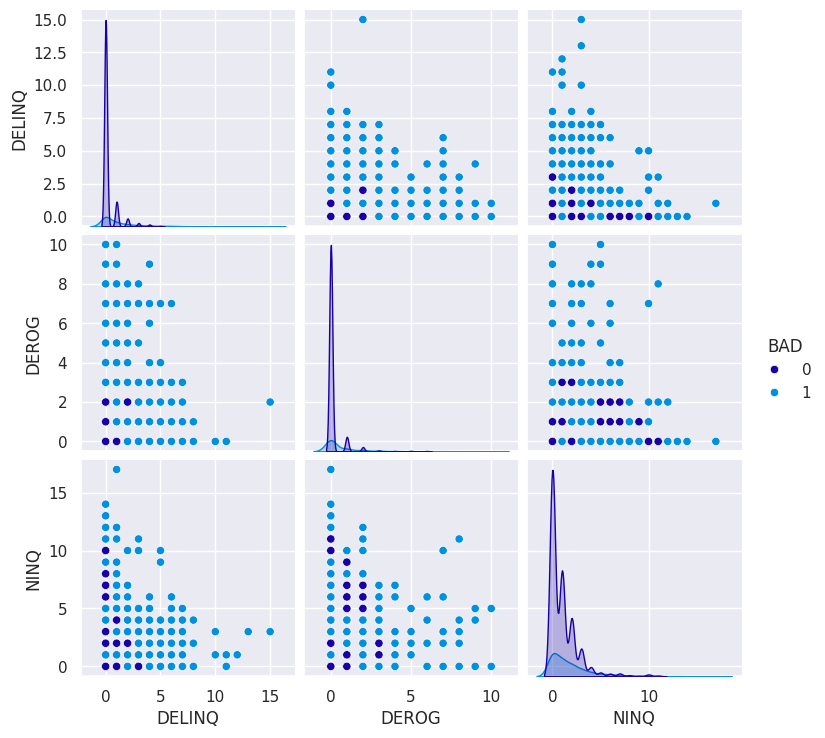

```python
numerical_features_for_pairplot = ['BAD', 'DELINQ', 'DEROG', 'NINQ']
sns.pairplot(df[numerical_features_for_pairplot], hue='BAD')
plt.show()
```

**Insight: From the more optimally selected pairplots**

From the missing value table, we have the following:

- BAD: 0 missing values (0.00%)
- DELINQ: 580 missing values (9.73%)
- DEROG: 708 missing values (11.88%)
- NINQ: 510 missing values (8.56%)

This shows that while 'BAD' has no missing values, 'DELINQ', 'DEROG', and 'NINQ' all have a moderate percentage of missing values (between ~8.5% and ~11.9%). These will need to be addressed before building a model.

#### **Treating Outliers:**

```python
def treat_outliers(df,col):
    '''
    treats outliers in a varaible
    col: str, name of the numerical varaible
    df: data frame
    col: name of the column
    '''
    Q3=df[col].quantile(0.75)
    IQR=Q3-df[col].quantile(0.25)
    Lower_Whisker = df[col].quantile(0.25)-(IQR*1.5)
    Upper_Whisker = df[col].quantile(0.75)+(IQR*1.5)
    df[col]=np.where(df[col]>Upper_Whisker,Upper_Whisker,df[col])
    df[col]=np.where(df[col]<Lower_Whisker,Lower_Whisker,df[col])
    return df


def treat_outliers_all(df, col_list):
    '''
    treat outlier in all numerical varaibles
    col_list: list of numerical varaibles
    df: data frame
    '''
    for c in col_list:
        df = treat_outliers(df,c)

    return df
```

```python
df_raw = df.copy()

# getting list of numerical columns, excluding 'BAD' from outlier treatment
numerical_col = df_raw.select_dtypes(include=np.number).columns.drop('BAD', errors='ignore').tolist()

df = treat_outliers_all(df_raw,numerical_col)
```

### **Re-converting categorical columns**

```python
# Re-convert 'REASON' and 'JOB' columns to 'category' dtype after df re-assignment.
cols_to_convert_to_category = ['REASON', 'JOB']
for col in cols_to_convert_to_category:
    if col in df.columns:
        df[col] = df[col].astype('category')

# Verify dtypes and missing values
print("DataFrame info after re-converting categorical columns:")
df.info()
```

```
DataFrame info after re-converting categorical columns:
<class 'pandas.core.frame.DataFrame'>
RangeIndex: 5960 entries, 0 to 5959
Data columns (total 13 columns):
 #   Column   Non-Null Count  Dtype
---  ------   --------------  -----
 0   BAD      5960 non-null   int64
 1   LOAN     5960 non-null   float64
 2   MORTDUE  5442 non-null   float64
 3   VALUE    5848 non-null   float64
 4   REASON   5708 non-null   category
 5   JOB      5681 non-null   category
 6   YOJ      5445 non-null   float64
 7   DEROG    5252 non-null   float64
 8   DELINQ   5380 non-null   float64
 9   CLAGE    5652 non-null   float64
 10  NINQ     5450 non-null   float64
 11  CLNO     5738 non-null   float64
 12  DEBTINC  4693 non-null   float64
dtypes: category(2), float64(10), int64(1)
memory usage: 524.3 KB
```

**Adding new columns in the dataset for each column which has missing values**

```python
#For each column we create a binary flag for the row, if there is missing value in the row, then 1 else 0.
def add_binary_flag(df,col):
    '''
    df: It is the dataframe
    col: it is column which has missing values
    It returns a dataframe which has binary falg for missing values in column col
    '''
    new_col = str(col)
    new_col += '_missing_values_flag'
    df[new_col] = df[col].isna()
    return df
```

```python
# list of columns that has missing values in it
missing_col = [col for col in df.columns if df[col].isnull().any()]

for colmn in missing_col:
    add_binary_flag(df,colmn)
```

**Filling missing values in numerical columns with median and mode in categorical variables**

```python
df['JOB'].value_counts(dropna=False)
```

| JOB | count |
| --- | --- |
| Other | 2388 |
| ProfExe | 1276 |
| Office | 948 |
| Mgr | 767 |
| NaN | 279 |
| Self | 193 |
| Sales | 109 |

**dtype:** int64

```python
df['REASON'].value_counts(dropna=False)
```

| REASON | count |
| --- | --- |
| DebtCon | 3928 |
| HomeImp | 1780 |
| NaN | 252 |

**dtype:** int64

```python
#  Treat Missing values in numerical columns with median and mode/new category in categorical variables

# Select numerical columns for imputation
# Exclude 'BAD' from imputation as it's the target variable and is already confirmed to have no missing values
numerical_cols_to_impute = df.select_dtypes('number').columns.drop('BAD', errors='ignore').tolist()

# Impute numerical columns with their median
for col in numerical_cols_to_impute:
    if df[col].isnull().any(): # Only impute if there are actual missing values
        df[col] = df[col].fillna(df[col].median())

# Explicitly define categorical columns to impute to ensure they are processed
categorical_cols_to_impute = ['REASON', 'JOB']

# Impute categorical columns with 'Missing' category using a more robust method
for col in categorical_cols_to_impute:
    if col in df.columns and df[col].isnull().any(): # Check if column exists and has missing values
        # Convert to object type, fill NaNs with 'Missing' string, then convert back to category
        df[col] = df[col].astype(object).fillna('Missing')
        df[col] = df[col].astype('category')
```

```python
# Check for any remaining missing values after imputation
print("Missing values after imputation:")
df.isnull().sum()
```

```
Missing values after imputation:
```

|  | 0 |
| --- | --- |
| BAD | 0 |
| LOAN | 0 |
| MORTDUE | 0 |
| VALUE | 0 |
| REASON | 0 |
| JOB | 0 |
| YOJ | 0 |
| DEROG | 0 |
| DELINQ | 0 |
| CLAGE | 0 |
| NINQ | 0 |
| CLNO | 0 |
| DEBTINC | 0 |
| MORTDUE_missing_values_flag | 0 |
| VALUE_missing_values_flag | 0 |
| REASON_missing_values_flag | 0 |
| JOB_missing_values_flag | 0 |
| YOJ_missing_values_flag | 0 |
| DEROG_missing_values_flag | 0 |
| DELINQ_missing_values_flag | 0 |
| CLAGE_missing_values_flag | 0 |
| NINQ_missing_values_flag | 0 |
| CLNO_missing_values_flag | 0 |
| DEBTINC_missing_values_flag | 0 |

**dtype:** int64

### **Important Insights from EDA:**

Based on the Exploratory Data Analysis, here are the key observations, insights, and conclusions:

**1. Data Overview and Quality:**

The dataset contains 5960 loan applicants and 13 features. BAD is the target variable, indicating loan default.

Significant missing values present across most features (from 1.88% in VALUE to 21.26% in DEBTINC), creates the need for careful data handling.

**2. Target Variable Imbalance:**

Approximately 19.9% of the loans in the dataset resulted in default (BAD=1), indicating a class imbalance that will need to be addressed in model training.

**3. Numerical Feature Insights:**

**Outliers:** Many numerical features, such as LOAN, MORTDUE, VALUE, DEBTINC, DEROG, DELINQ, CLAGE, NINQ, and CLNO, shows presence of outliers.

**Distributions: **Features like DEROG, DELINQ, and NINQ are heavily skewed towards zero, meaning most applicants have few (0-4) or no derogatory reports, delinquencies, or recent inquiries.

**DEBTINC (Debt-to-Income Ratio):** This feature has the highest percentage of missing values and also shows a wide range with outliers, making its careful handling crucial.

**4. Categorical Feature Insights:**

**REASON (Loan Purpose):** 'DebtCon' (Debt Consolidation) is the most common reason for loans (around 66%), but 'HomeImp' (Home Improvement) loans have a slightly higher default rate (22.25%) compared to 'DebtCon' (18.96%).

**JOB (Job Category):** 'Other' is the most frequent job category (around 40%). Job categories show varying default rates, with **'Sales' (34.86%)** and **'Self' (30.05%) having the highest default rates, while 'Office' (13.19%) and 'ProfExe' (16.61%) have the lowest.**

**5. Bivariate Relationships (BAD vs. Features):**

**DEBTINC:** Higher debt-to-income ratios appear to be associated with a higher likelihood of default.

Other Numerical Features: There is a **strong positive correlation between property VALUE and MORTDUE.** Defaulting loans (BAD=1) in the scatter plot appeared more scattered, especially where MORTDUE was high relative to VALUE.

**6. Multivariate Analysis (Correlation Heatmap):**

It also highlighted the high multicollinearity between MORTDUE and VALUE.

**Conclusion:** Features related to credit history (DELINQ, DEROG, NINQ), debt burden (DEBTINC), and job stability (JOB categories like 'Sales' and 'Self') are emerging as crucial indicators for predicting loan defaults.

The preprocessing steps undertaken (outlier treatment, missing value flagging, and imputation) have prepared the data for model building, ensuring robustness and minimizing information loss.

## **Model Building - Approach**

1. Data preparation
2. Partition the data into train and test set
3. Fit on the train data
4. Tune the model and prune the tree, if required
5. Test the model on test set

### **Data Preparation**

**Separating the target variable from other variables**

```python
# Drop the dependent variable from the dataframe and create the X(independent variable) matrix
X = df.drop('BAD',axis=1)

# Create dummy variables for the categorical variables - Hint: use the get_dummies() function
X = pd.get_dummies(X)

# Create y(dependent varibale)
y = df['BAD']

# Convert to numpy arrays
X = X.values
y = y.values
```

**Splitting the data into 70% train and 30% test set**

```python
## Import Data Split function from sklearn
from sklearn.model_selection import train_test_split

# Split the data into 70% training and 30% test set
X_train, X_test, y_train, y_test = train_test_split(X, y, test_size=0.3, random_state=42)
```

```python
print('Shape of X_train:', X_train.shape)
print('Shape of X_test:', X_test.shape)
print('Shape of y_train:', y_train.shape)
print('Shape of y_test:', y_test.shape)
```

```
Shape of X_train: (4172, 31)
Shape of X_test: (1788, 31)
Shape of y_train: (4172,)
Shape of y_test: (1788,)
```